# Machine Learning Project

SJR

12/12/2016

## Human Activity Recognition

The data for this project comes from http://groupware.les.inf.puc-rio.br/har. It is licensed under the **Creative Commons licence (CC BY-SA)**.

The analysis was performed on a Mac OS X Yosemite 10.10.5 using RStudio v 1.0.44 with the following libraries loaded:

- Caret version 6.0-73
- Rattle version 4.1.0
- rpart version 4.1-10
- rpart.plot version 2.1.0
- randomForest version 4.6-10

### Backgound

Using devices such as Jawbone Up, Nike FuelBand, and Fitbit it is now possible to collect a large amount of data about personal activity relatively inexpensively. These type of devices are part of the quantified self movement – a group of enthusiasts who take measurements about themselves regularly to improve their health, to find patterns in their behavior, or because they are tech geeks. One thing that people regularly do is quantify how much of a particular activity they do, but they rarely quantify how well they do it. In this project, your goal will be to use data from accelerometers on the belt, forearm, arm, and dumbell of 6 participants. They were asked to perform barbell lifts correctly and incorrectly in 5 different ways. More information is available from the website here: http://groupware.les.inf.puc-rio.br/har - see the section on the Weight Lifting Exercise Dataset.

### Data

The training and testing data for this project are available here:

- https://d396qusza40orc.cloudfront.net/predmachlearn/pml-training.csv
- https://d396qusza40orc.cloudfront.net/predmachlearn/pml-testing.csv

### Loading and preparing the data

1. Download, rename, save, and read data

```r
trainURL <- "https://d396qusza40orc.cloudfront.net/predmachlearn/pml-training.csv"
download.file(trainURL, destfile = "./train.csv", method = "curl")
testURL <- "https://d396qusza40orc.cloudfront.net/predmachlearn/pml-testing.csv"
download.file(testURL, destfile = "./test.csv", method = "curl")
training <- read.csv("./train.csv", na.strings = c("NA", "#DIV/0!", ""))
testing <- read.csv("./test.csv", na.strings = c("NA", "#DIV/0!", ""))
dim(training); dim(testing)
```

```
## [1] 19622   160
```

```
## [1]  20 160
```

2. Clean the dataset and prepare it for analysis by performing the following steps:
- Remove the first 7 columns from the *training & testing* datasets as they have no impact on our analysis

```r
training <- training[, -c(1:7)]; testing <- testing[, -c(1:7)]
```

- Remove all variables that have to many NA values using the colSums function

```r
training <- training[, colSums(is.na(training)) == 0]
testing <- testing[, colSums(is.na(testing)) == 0]
dim(training); dim(testing)
```

```
## [1] 19622    53
```

```
## [1] 20 53
```

3. Partition the training data into 2 datasets (70% training, 30% testing)

```r
library(caret)
set.seed(1234)
inTrain <- createDataPartition(y=training$classe, p=0.7, list=FALSE)
train <- training[inTrain,]; test <- training[-inTrain,]
```

### Prediction Model Algorithms

In building the prediction model for our analysis, I will use the Random Forest model by fitting the *Train* dataset using a 4-fold cross-validation, as well as the Decision Tree model. I will evaluate the results, re-train the selection model and finally, make a prediction using the *Test* dataset.

#### Random Forest

```r
library(randomForest)
control <- trainControl(method="cv", number = 4, verboseIter = FALSE)
fitModelRF <- train(classe ~ ., data = train, method = "rf", trControl = control)
fitModelRF$finalModel
```

```
##
## Call:
##  randomForest(x = x, y = y, mtry = param$mtry)
##                Type of random forest: classification
##                      Number of trees: 500
## No. of variables tried at each split: 27
##
##         OOB estimate of  error rate: 0.7%
## Confusion matrix:
##      A    B    C    D    E class.error
## A 3899    4    2    0    1 0.001792115
## B   19 2632    7    0    0 0.009781791
## C    0   14 2377    5    0 0.007929883
## D    0    0   31 2219    2 0.014653641
## E    0    1    3    7 2514 0.004356436
```

The Random Forest model used 500 tress with 27 variable at each split with an *out-of-bag (OOB)* error rate of 0.7%, which basically represents our *test* dataset.

Now, I will predict the outcome for out-of sample accuracy on the *test* data, show the confusion matrix, and compare predicted versus actual

```r
predictRF <- predict(fitModelRF, newdata = test)
confusionMatrix(test$classe, predictRF)
```

```
## Confusion Matrix and Statistics
##
##           Reference
## Prediction    A    B    C    D    E
##          A 1674    0    0    0    0
##          B    3 1135    1    0    0
##          C    0    1 1024    1    0
##          D    0    1    3  960    0
##          E    0    1    1    0 1080
##
## Overall Statistics
##
##                Accuracy : 0.998
##                  95% CI : (0.9964, 0.9989)
##     No Information Rate : 0.285
##     P-Value [Acc > NIR] : < 2.2e-16
##
##                   Kappa : 0.9974
##  Mcnemar's Test P-Value : NA
##
## Statistics by Class:
##
##                      Class: A Class: B Class: C Class: D Class: E
## Sensitivity            0.9982   0.9974   0.9951   0.9990   1.0000
## Specificity            1.0000   0.9992   0.9996   0.9992   0.9996
## Pos Pred Value         1.0000   0.9965   0.9981   0.9959   0.9982
## Neg Pred Value         0.9993   0.9994   0.9990   0.9998   1.0000
## Prevalence             0.2850   0.1934   0.1749   0.1633   0.1835
## Detection Rate         0.2845   0.1929   0.1740   0.1631   0.1835
## Detection Prevalence   0.2845   0.1935   0.1743   0.1638   0.1839
## Balanced Accuracy      0.9991   0.9983   0.9974   0.9991   0.9998
```

Our prediction yields an accuracy rate of 99.8% with a 0.2% OOB.

#### Decision Tree

```r
library(rattle)
fitModelDT <- train(classe ~ ., data = train, method = "rpart", trControl = control)
print(fitModelDT, digits = 4)
```

```
## CART
##
## 13737 samples
##    52 predictor
##     5 classes: 'A', 'B', 'C', 'D', 'E'
##
## No pre-processing
## Resampling: Cross-Validated (4 fold)
## Summary of sample sizes: 10302, 10303, 10303, 10303
## Resampling results across tuning parameters:
##
##   cp       Accuracy  Kappa
##   0.03550  0.5286    0.39603
##   0.06093  0.4000    0.18143
##   0.11738  0.3459    0.09413
##
## Accuracy was used to select the optimal model using  the largest value.
## The final value used for the model was cp = 0.0355.
```

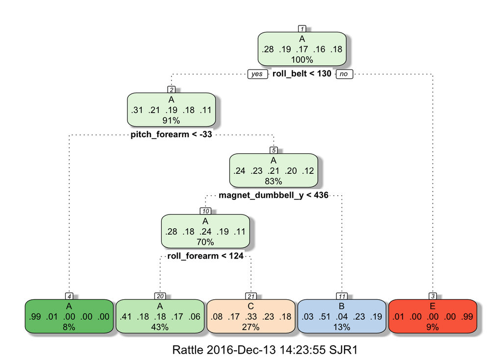

```r
fancyRpartPlot(fitModelDT$finalModel)
```

Predict the outcome for out-of sample accuracy on the *test* data, show the confusion matrix, and compare predicted versus actual

```r
predictDT <- predict(fitModelDT, newdata = test)
confusionMatrix(test$classe, predictDT)
```

```
## Confusion Matrix and Statistics
##
##           Reference
## Prediction    A    B    C    D    E
##          A 1530   35  105    0    4
##          B  486  379  274    0    0
##          C  493   31  502    0    0
##          D  452  164  348    0    0
##          E  168  145  302    0  467
##
## Overall Statistics
##
##                Accuracy : 0.489
##                  95% CI : (0.4762, 0.5019)
##     No Information Rate : 0.5317
##     P-Value [Acc > NIR] : 1
##
##                   Kappa : 0.3311
##  Mcnemar's Test P-Value : NA
##
## Statistics by Class:
##
##                      Class: A Class: B Class: C Class: D Class: E
## Sensitivity            0.4890   0.5027   0.3279       NA  0.99151
## Specificity            0.9478   0.8519   0.8797   0.8362  0.88641
## Pos Pred Value         0.9140   0.3327   0.4893       NA  0.43161
## Neg Pred Value         0.6203   0.9210   0.7882       NA  0.99917
## Prevalence             0.5317   0.1281   0.2602   0.0000  0.08003
## Detection Rate         0.2600   0.0644   0.0853   0.0000  0.07935
## Detection Prevalence   0.2845   0.1935   0.1743   0.1638  0.18386
## Balanced Accuracy      0.7184   0.6773   0.6038       NA  0.93896
```

The result of our prediction using the Decision Tree is not very impressive. In fact, we were only able to achieve a 48.90% accuracy with an OOB of 51.1%, a value much larger than our *test* dataset of 30%.

### Re-Training the Model

```r
fit <- train(classe ~ ., data = training, method = "rf", trControl = control)
fit$finalModel
```

```
##
## Call:
##  randomForest(x = x, y = y, mtry = param$mtry)
##                Type of random forest: classification
##                      Number of trees: 500
## No. of variables tried at each split: 2
##
##         OOB estimate of  error rate: 0.44%
## Confusion matrix:
##      A    B    C    D    E  class.error
## A 5577    2    0    0    1 0.0005376344
## B   15 3778    4    0    0 0.0050039505
## C    0   15 3407    0    0 0.0043834015
## D    0    0   43 3171    2 0.0139925373
## E    0    0    0    5 3602 0.0013861935
```

```r
predictF <- predict(fit, testing)
predictF
```

```
##  [1] B A B A A E D B A A B C B A E E A B B B
## Levels: A B C D E
```